# Hw_9

Pranita

2025-04-21

# name: Pranita Chaudhury

# UT ID: pc28377

# github: https://github.com/PranitaChau/Hw_9

# Problem 1

## Part A

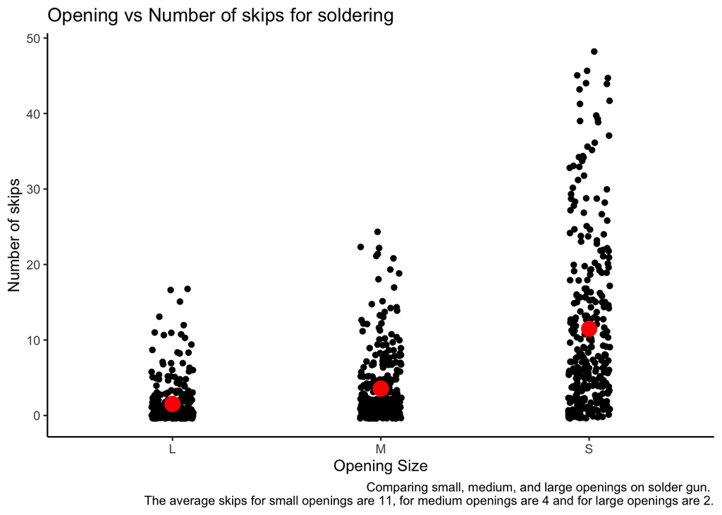

```
##  L  M  S
##  2  4 11
```

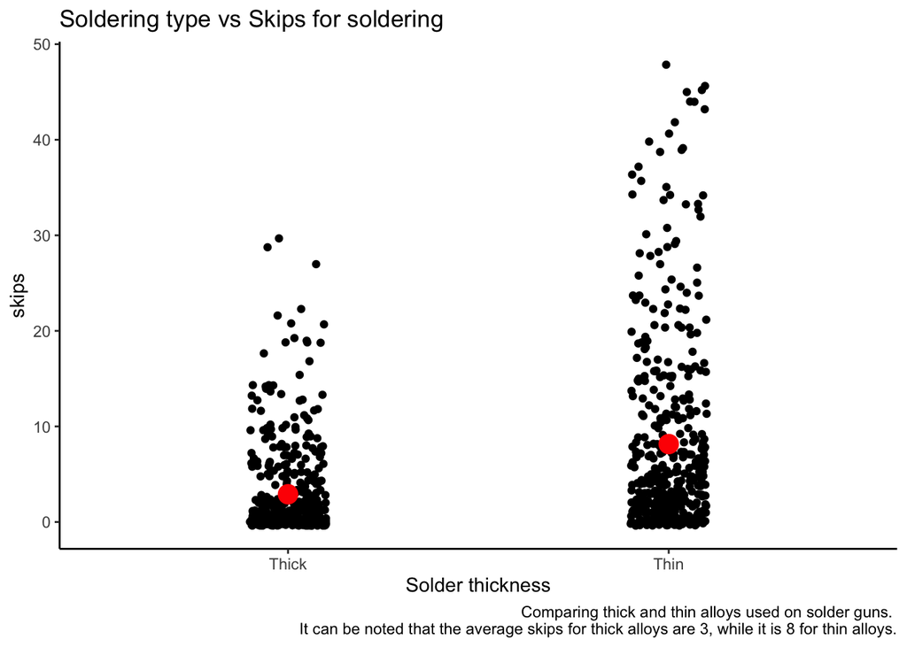

```
## Thick  Thin
##     3     8
```

## Part B

```
##         (Intercept)            OpeningM            OpeningS          SolderThin
##                   0                   2                   5                   2
## OpeningM:SolderThin OpeningS:SolderThin
##                  -1                  10
```

```
##       Intercept OpeningM OpeningS SolderThin OpeningM.SolderThin
## 2.5%  0.2344283 1.816427 4.350272   1.839081           -2.122089
## 97.5% 0.5387792 3.272440 5.987795   2.869602            0.618722
##       OpeningS.SolderThin
## 2.5%             7.537138
## 97.5%           11.408365
```

Regression model: Skips = 2(Opening_Medium) + 5(Opening_Small) + 2(SolderThin) - (Opening_Medium)(SolderThin) + 10 (Opening_Small)(SolderThin)

## Part C

The baseline number of skips is 0, which represents boards with a large opening and thick solder. This intercept also refers to all interactions involving these baseline levels, since their coefficients are set to zero. The main effect for medium Openings is 2 skips, this is the effect of OpeningM in isolation. The main effect for small Openings is 5 skips, this is the effect of OpeningS in isolation. The main effect for thin solders is 2 skips, this is the effect of SolderThin in isolation. The interaction effect for OpeningM and SolderThin is -1 skips. In other words, circuits which had both medium openings and thin solders used average 1 less skips than what you would expect from summing the individual “isolated” effects of the two variables. The interaction effect for OpeningS and SolderThin is 10 skips. In other words, circuits which had both small openings and thin solders used average 10 more skips than what you would expect from summing the individual “isolated” effects of the two variables.

## Part D

If I had to recommend a combination of opening size and solder thickness to AT&T based on this analysis I would recommend they use a large opening and a thick solder since this is the most likely to result in 0 skips, which is the lowest number of skips possible.

# Problem 2

## Part A

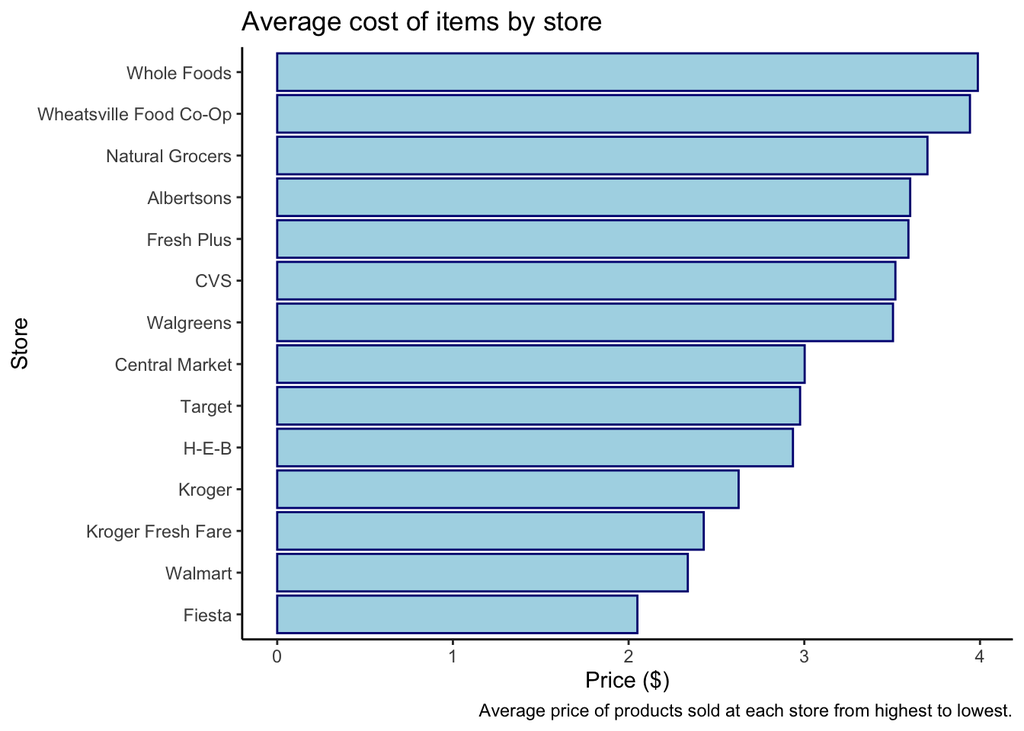

We can see price differences of $0-$2 when comparing all products in the store, and the specific difference would depend no whch stores are being compared.